# The ROOT file

- With ROOT, objects can be written to files
- ROOT provides its own file class, [TFile](https://root.cern/doc/master/classTFile.html), to interact with these files
- ROOT files are *binary* and can be transparently *compressed* to reduce disk usage
- ROOT files have a logical “file-system-like” structure
  - E.g. a directory hierarchy

Let's start with importing ROOT as usual

```python
import ROOT
```

This is how you create a `TFile`:

```python
f = ROOT.TFile("my_file.root", "RECREATE")
```

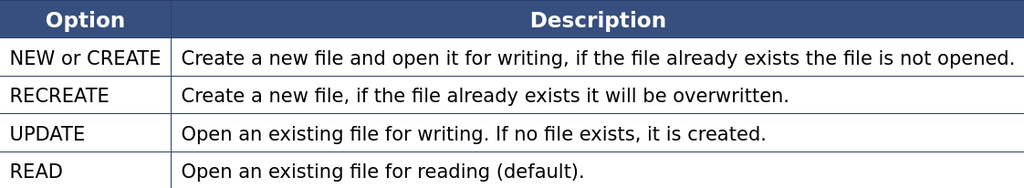

and how you close it (note that when `f` is destroyed, the file is closed automatically):

```python
f.Close()
```

Note that you can use the Python context manager syntax for opening a TFile, which will automatically run the necessary cleanup for you:

```python
with ROOT.TFile("my_file.root", "RECREATE") as myfile:
    # do something with the file inside the scope
    pass
```

With the following example we demonstrate how to write an object inside a file:

```python
with ROOT.TFile("my_file.root", "RECREATE") as f:
    h = ROOT.TH1D("my_histo", "Example histogram", 100, -4, 4)
    f.WriteObject(h, h.GetName())
```

The `"my_histo"` argument of the `TH1D` constructor is the name of the histogram, and it is also how it will be identified inside the file, we'll see that in a minute.

We should now have a file called `my_file.root` in the current directory. We will check that by using the `%%bash` magic, which allows us to run bash commands from a cell:

```python
%%bash
ls -l my_file.root
```

[output not shown]

```python
%%bash
rootls -l my_file.root
```

[output not shown]

Finally, let's see how we can programmatically retrieve the histogram we just wrote in the file.

We can access the histogram by its name using `TFile::Get()`.

```python
with ROOT.TFile("my_file.root") as f: # READ is the default mode
    h = f.Get("my_histo")
    print(h)
```

```
Name: my_histo Title: Example histogram NbinsX: 100
```

# The HEP dataset

High Energy Physics data is made of many statistically independent collision events.

Laying data into an "event class", then serialise and write out `N` instances of the class into a file would be very inefficient.

In ROOT, a dataset is organised columns that can store elements of any C++ type:

- fundamental types: `int`, `float`
- C++ standard collections: `std::vector`, `std::map`
- User created C++ classes

The ROOT dataset is represented by the `TTree` class and is often simply called a tree. Columns in the dataset are instances of the `TBranch` class (often referred to as "branches").

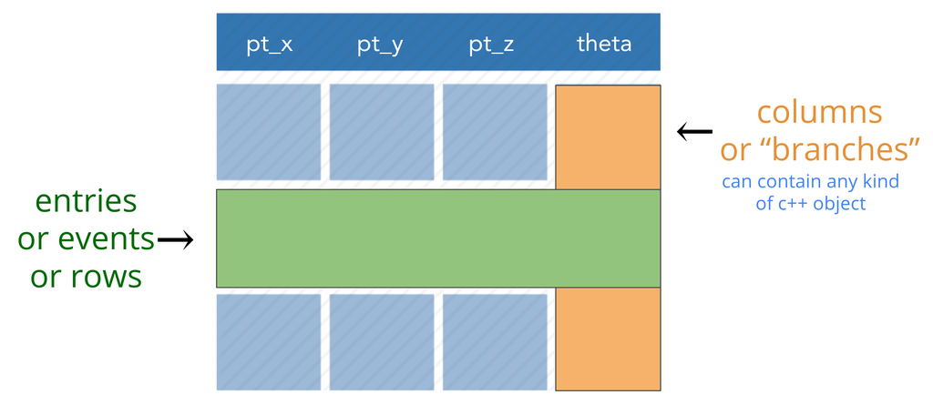

- A `TTree` dataset can be written to a `TFile` (just like any other C++ object).
- The ROOT format is logically and physically (on disk) a columnar format.
- Different columns can be read from disk independently.
- This translates into faster IO performance with respect to other dataset formats (HDF5, SQL).

```python
%%bash
rootls -l ../../data/example_file.root
```

```
TTree  Aug 25 14:32 2021 dataset;1 "dataset"
```